# 11_A_TS_BoxCox_Transformation

# Libraries

```r
library(fpp3)
```

# References

1. Hyndman, R.J., & Athanasopoulos, G., 2021. Forecasting: principles and practice. 3rd edition.

# Note:

This notebook is not original material, but rather an expansion of reference 1 (which is publicly available) with additional comments and explanations given by the professor to help students understand the concepts.

# Mathematical transformations

The transformations we are going to use in the context of time series are **useful**:

1. If the data shows **variation that increases or decreases with the level of the series**. That is, if it is multiplicative to a certain extent.
2. If the data is a simple exponential trend they can help linearize it (at the cost of interpretability).

Notation:

- Original series: $y_1,\;...,y_t$.
- Transformed series: $w_1,\;...,w_t$.

## log() transformations

$$\begin{align*}
\boxed{w_t = log(y_t)}
\end{align*}$$

**NOTE:** the **log** function returns the **natural logarithm**. Natural logarithms (base $e$) are actually the reference for the rest of the logarithms. There are multiple reasons for this (beyond the scope of this course), the main one being that the derivative of $e^x$ is actually $e^x$. This has very important implications, particularly in the field of differential equations (general culture comment, beyond the scope of this course).

As a reminder of the properties of logarithms, you should be comfortable enough with their basic properties to derive these two equations easily. It is not necessary for this course, but proving these two statements would help you refresh your logarithm algebra (left for the student who wants to devote some time to this):

- $a^x = e^{xLn(a)}$
- $log_a(x) = \frac{log_b(x)}{log_b(a)}$

### Interpretation of logarithms

Changes in a log value are relative (or percentage) changes on the original scale. Example with log base 10:

- An increase of 1 on the $log_{10}$ scale corresponds to multiplying by 10 on the original scale.

We do not have time to cover this in class, and it should already have been clarified by other professors (particularly those teaching Data Visualisation). I will upload a video to blackboard covering this.

### Transformation $log(1+x)$

If the data contains either zeros or negative values, logarithms are not possible, since the real logarithm is only defined for $x > 0$.

If the data contains zeros and no negative values, then the transformation $log(1+x)$ can be useful:

- $log(1+x)$ can be useful for data with zeros that we feel would benefit from a log transformation. You can use the function `log1p()` directly for this. If $x$ has zeros but no negative values, $1+x$ will only have positive values, so $log(1+x)$ will exist and the transformation will be possible.

**Question:** why is this transformation good when we have data with zeros? Specifically, why is $1$ added to $x$, and not another positive real constant $k>0$?

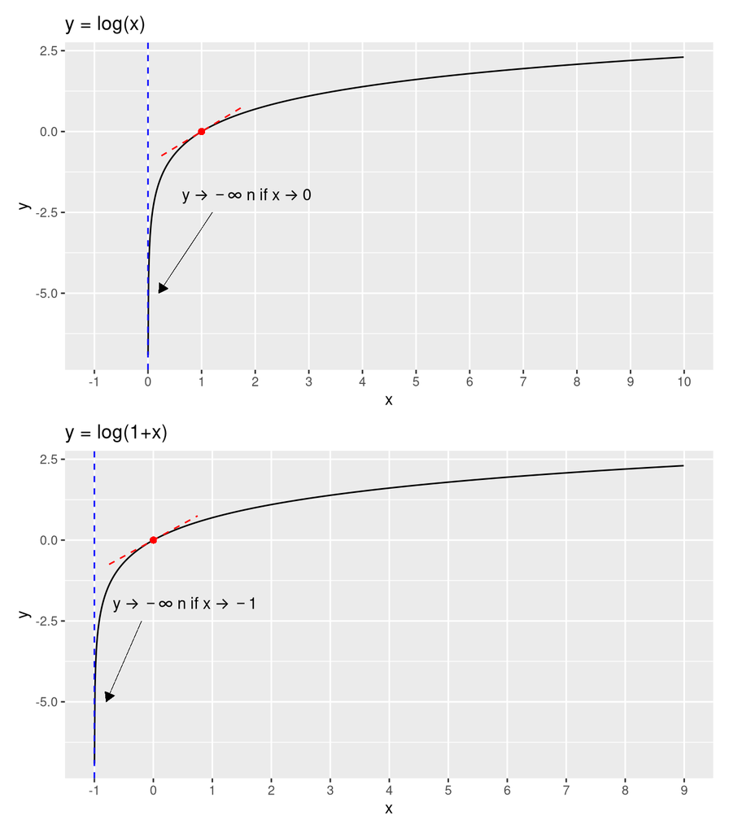

```r
1. The first and most important advantage is that 0s
   in the original scale are also 0s in the
   transformed scale (if x = 0 then y = log(1+x) = 0).

2. The second advantage is that the function log(1+x) can be linearly
   approximated by x in the vicinity of 0. See tangent lines in
   the graph above.
```

## Power transformations

$$\begin{align*}
w_t = y_t^p
\end{align*}$$

They are not as interpretable as the logarithmic transformation. They also tend to stabilize seasonal variations, as we saw in the example of the anti-diabetic drug sales (see the introductory session to time series decomposition, where the concept of additive vs multiplicative schemes is introduced).

## Box-Cox transformations

This transformation includes both logarithms and power transformations. The specific transformation performed depends on the parameter $\lambda$.

$$\begin{equation}
w_t =
\begin{cases}
\log(y_t) & \text{if $\lambda=0$}; \\
(\text{sign}(y_t)|y_t|^\lambda-1)/\lambda & \text{otherwise}.
\end{cases}
\end{equation}$$

**Question:** what is the difference between a variable and a parameter?

```r
In a function such as the Box-Cox transformation that has both parameters and
variables:

* The variables (in this case y_t) define the domain of the function. In this
case the domain of the function is the range of possible values for y_t. The
function could have more than one variable.

* The parameters (in this case lambda) also take a range of values. Once we set
a specific  value for the parameters, we proceed to study the behavior of the
function: the possible values its variables (y_t in this case) may take and the
resulting values of the function.

Depending on the specific value of the parameters, the function behaves in
one or other manner. That is, for each specific value of the parameters, we
have one or other "version" or "behavior" of the function.

In the box-cox transformation, lambda is the parameter and y_t is the variable.
```

The Box-Cox transformation also attempts to stabilize the seasonal fluctuations and random variations. Specifically, it addresses cases where the variance of the time series grows with the level of the series.

The following [link](https://otexts.com/fpp3/transformations.html#mathematical-transformations) leads to an interactive graph that clarifies the effect of $\lambda$ on the box-cox transformation in the context of time series.

- The logarithm in a Box-Cox transformation is **always a natural logarithm**.
  - $\lambda = 1$: no substantial transformation. Data is simply shifted downwards. ($w_t = y_t -1$)
  - $\lambda = 0$: transformation equivalent to a natural logarithm.
  - $\lambda = 1/2$: Square root + scaling transformation
  - $\lambda = 1/3$: Cubic root + scaling transformation
  - $\lambda = -1$: Inverse transformation (+ 1)
- **Considerations when using this transformation**:
  - If some data are zero or negative, use $\lambda > 0$, since the real logarithm is not defined in this case.
  - Always check your results by plotting the time series.
  - A low value of $\lambda$ can result in extremely large prediction intervals.
  - If the best value of $\lambda$ is very close to 0, prefer a log transformation, since it has much better interpretability.
  - The final judge of the transformation is the performance of the model you are trying to use, and the uncertainty associated with its predictions (prediction intervals). Throughout the course we will learn how to evaluate the performance of our models.

### Guerrero feature to pick a value for the parameter lambda

The Guerrero feature suggests a value of lambda that results in the best Box-Cox transformation to make the scheme of the series additive. Like most methods, it does not work 100% of the time, but for most cases it will result in a good value to render the scheme of the series additive.

Let us look at the gas production in Australia:

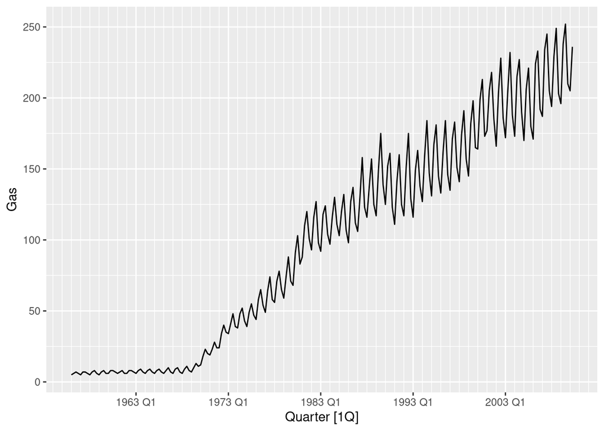

```r
aus_production |>
  autoplot(Gas) +
  scale_x_yearquarter(
    breaks = "10 years",
    minor_breaks = "1 year"
  )
```

In the example below we apply it to the `Gas` time series within the dataset `aus_production`, loaded along with `fpp3`.

```r
lambda <- aus_production |>
  features(Gas, features = guerrero) |>
  pull(lambda_guerrero)

lambda
```

```
[1] 0.1095171
```

The suggested value of lambda is 0.11. It is relatively close to 0, so we could compare the output of the box-cox transformation with that of the log transformation

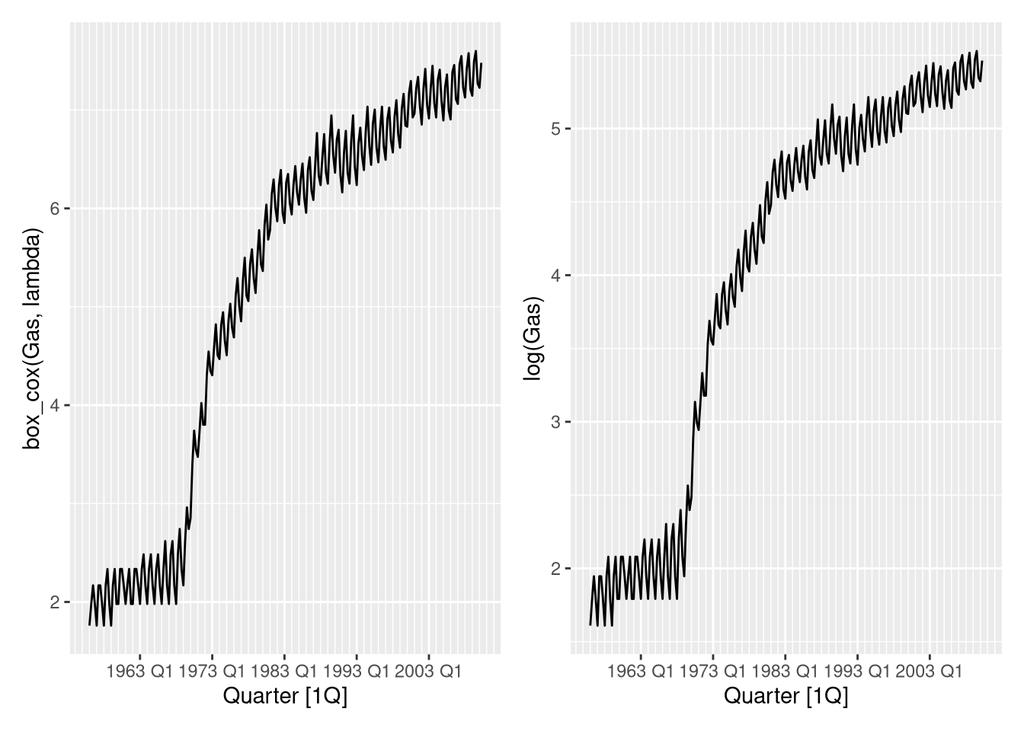

```r
p1 <-
aus_production |>
  autoplot(box_cox(Gas, lambda)) +
  scale_x_yearquarter(
    breaks = "10 years",
    minor_breaks = "1 year"
  )

p2 <-
aus_production |>
  autoplot(log(Gas)) +
  scale_x_yearquarter(
    breaks = "10 years",
    minor_breaks = "1 year"
  )

p1 + p2
```

In this particular case, the box-cox transformation seems slightly better at stabilizing the variance. But choosing it over the log transformation means losing interpretability in the transformed domain, and a small value for lambda usually results in worse prediction intervals than with the log transformation. A simple log transformation would work well enough and be better in terms of prediction intervals.

### Usual workflow with the Box-Cox transformation

If you decide that a Box-Cox transformation could help for the case at hand, the flowchart below is a general outline of the process:

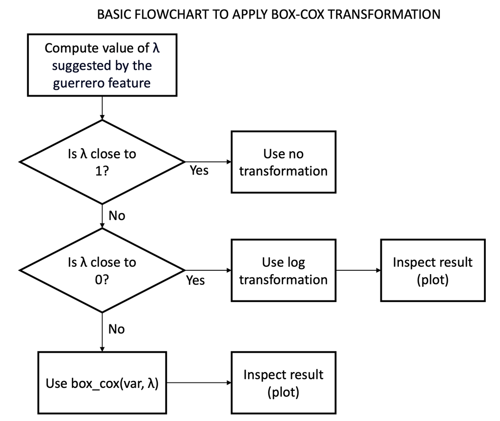

1. Check the value of lambda suggested by the `guerrero` feature.
2. If the value of lambda is very close to 1, do not apply a transformation, since the Box-Cox transformation will barely have a noticeable effect yet do away with the interpretability of the variable.
3. If the value of lambda is very close to 0, apply a $log()$ transformation instead, since its effect will be very similar and it preserves interpretability.
4. If the value of lambda is neither close to 0 nor close to 1, apply the Box-Cox transformation.

In the end, always check the result by plotting the data. You may also add quantitative metrics such as the moving standard deviation (not covered in this course) to help you judge whether the variance still increases with the level of the series after the transformation, or whether it has been stabilized.

The examples and homework at the end of the notebook will bring clarity to this process.

### Caveat of Box-Cox-like transformations

Power transformations (such as the Box-Cox transformation) require the variability of the series to vary proportionally to the level of the series.

Let us look at data about the production of gas in Canada:

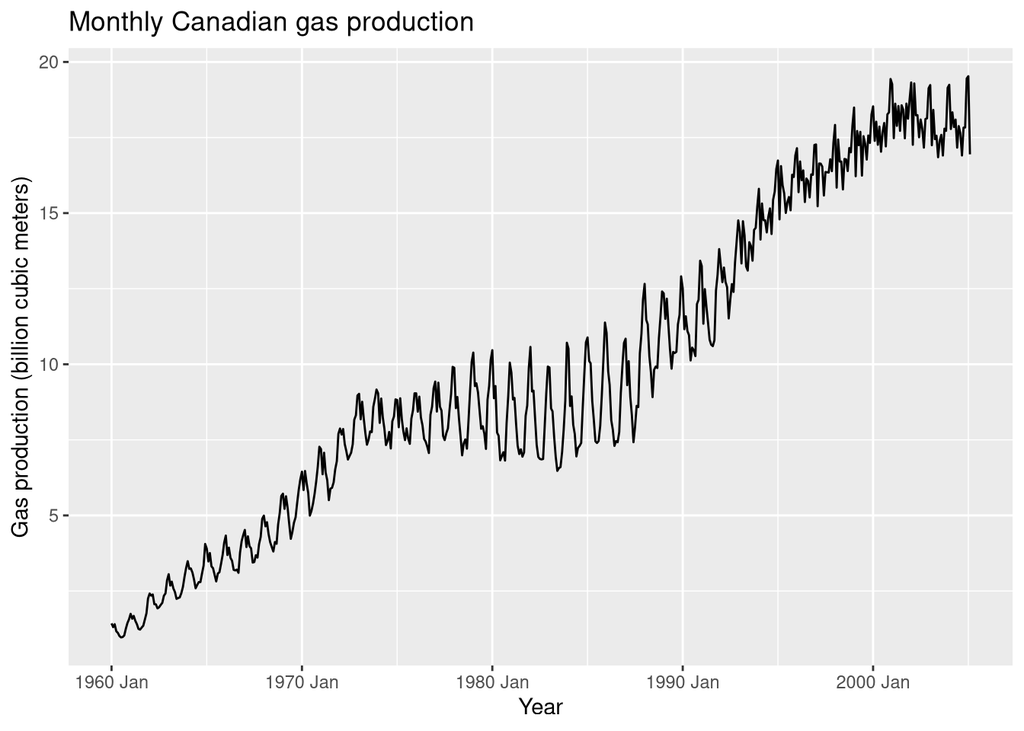

```r
canadian_gas |>
  autoplot(Volume) +
  labs(
    x = "Year", y = "Gas production (billion cubic meters)",
    title = "Monthly Canadian gas production"
  )
```

- The variation of the series is not proportional to the amount of gas produced in Canada.
  - **For small and large production levels:** small variations in the seasonal pattern.
  - **For moderate production levels** (between 1975 and 1990): the variation in the seasonal pattern is large.

In this case the Box-Cox transformation would not be of much help to render the variance of the seasonal component independent of the level of the series.

## Advanced - other transformations for data with 0s or negative values

The following [article](https://robjhyndman.com/hyndsight/transformations/) is worth reading. This is beyond the scope of the course, but it is a good reference if you ever face this issue.

## Some notes on transformations

- Often no transformation is needed, and we are able to produce a good forecast with the original data. Do not transform just for the sake of transforming — the goal is to make the data more palatable for a model so that it improves its performance.
  - The final judge of the transformation is the performance of the model you are trying to use, and the uncertainty associated with its predictions (prediction intervals). Throughout the course we will learn how to evaluate the performance of our models.
- Transformations that have good interpretability (such as log transformations) are preferred if they work well enough.
- Transformations can have a very large effect on prediction intervals.
- Transformations must be reversed to obtain forecasts on the original scale.

# Examples

For each of the following series, make a graph of the data. If transforming seems appropriate, do so and describe the effect.

```r
retail_series <- aus_retail |>
  filter(`Series ID` == "A3349767W")
```

### Example 1. United States GDP from global economy:

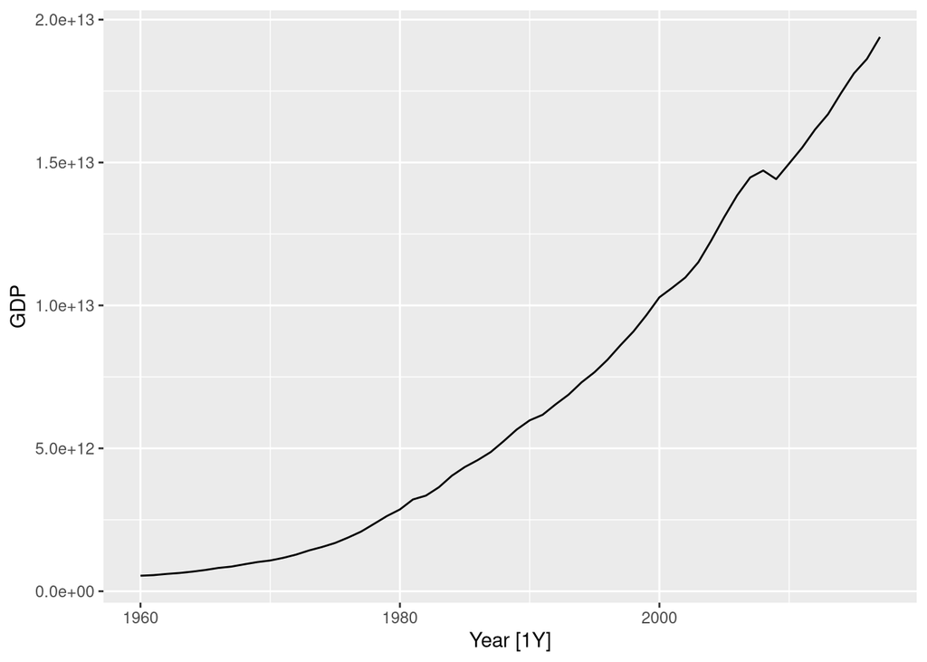

```r
us_economy <- global_economy |>
  filter(Country == "United States")
us_economy |>
  autoplot(GDP)
```

In the graph above, the derivative increases with the level of the series (the derivative is the slope of the tangent to the graph at each point). This is another form of increasing variance with the level of the series — a non-linear multiplicative trend. The Box-Cox transformation is also useful to address this.

#### We’ll discuss potential solutions during the live session.

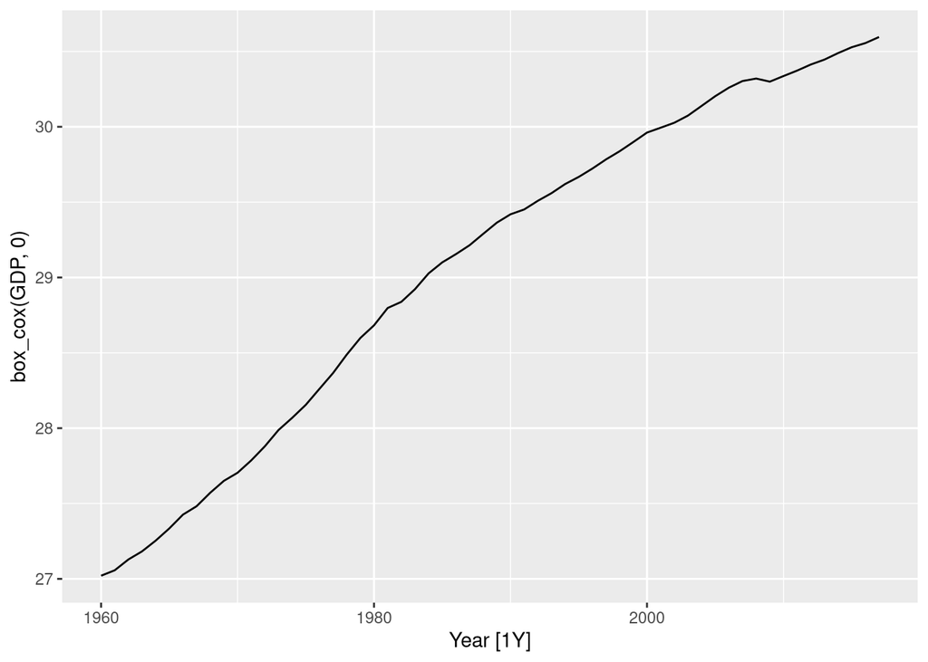

```r
# The trend is non-linear and multiplicative. Let us attempt to render it linear with a transformation
us_economy |>
  autoplot(box_cox(GDP, 0))
```

```r
A log transformation (Box-Cox with $\lambda = 0$) appears too strong.
Let's see what Guerrero's method suggests:
```

```r
lambda <- us_economy |>
  features(GDP, features = guerrero) |>
  pull(lambda_guerrero)

lambda
```

```
[1] 0.2819443
```

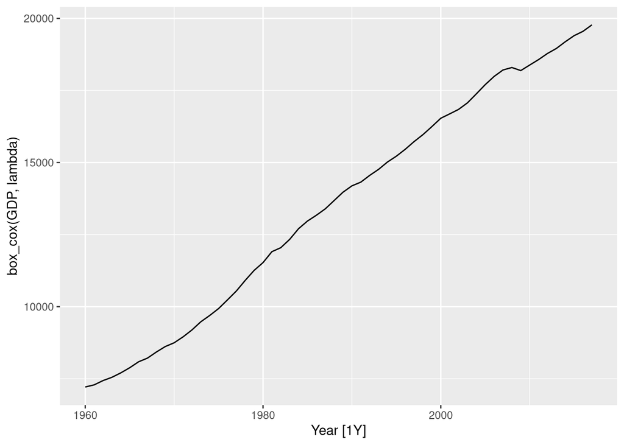

```r
us_economy |>
  autoplot(box_cox(GDP, lambda))
```

```r
The result is much more linear.

Yet we have lost all the interpretability of the response variable. We no longer
have a simple, interpretable relationship between the transformed variable and
the original variable.

Also, transformations can have a substantial effect on the prediction intervals.

To judge if the transformation is worth it, we could compare models fitted to the
original data and models fitted to the transformed data using cross-validation.
We will study this throughout the course.

But in principle, our decision flowchart tells us we should apply the Box-Cox
transformation with the estimated lambda to render the data additive.
```

### Example 2. Slaughter of Victorian “Bulls, bullocks and steers”

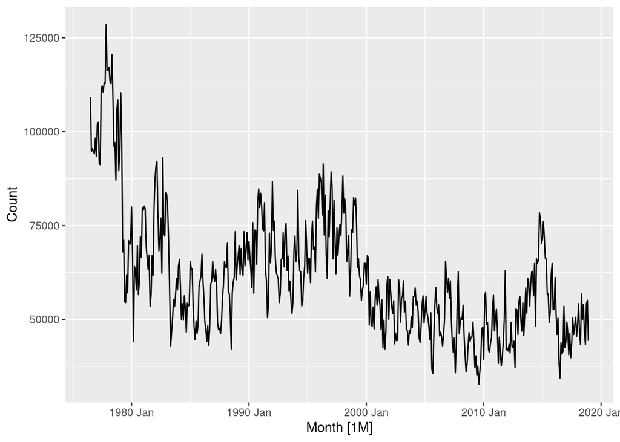

```r
vic_bulls <- aus_livestock |>
  filter(State == "Victoria", Animal == "Bulls, bullocks and steers")
vic_bulls |>
  autoplot(Count)
```

#### We’ll discuss potential solutions during the live session.

```r
The variation of the series appears to vary slightly with the number of bulls
slaughtered. A transformation could be useful.

Let us see what the Guerrero feature suggests:
```

```r
vic_bulls |>
  features(Count, features = guerrero)
```

```
# A tibble: 1 × 3
  Animal                     State    lambda_guerrero
  <fct>                      <fct>              <dbl>
1 Bulls, bullocks and steers Victoria         -0.0446
```

```r
The suggested value of lambda is so small that it is best to perform a log
transformation (which corresponds to lambda = 0), since it at least preserves
the interpretability of the data.

Let's compare the original and the transformed data:
```

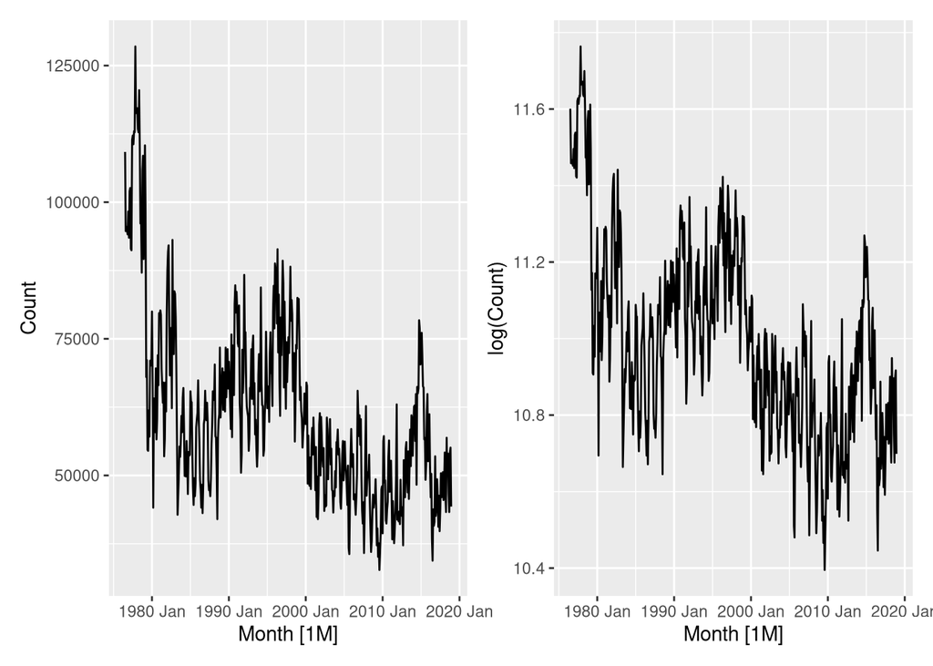

```r
p1 <- vic_bulls |> autoplot(Count)
p2 <- vic_bulls |>
  autoplot(log(Count))

p1 + p2
```

```r
The transformation does not seem to achieve much in terms of variance stabilization,
because the homoskedasticity of this particular time series is not of the
multiplicative type — or not clearly multiplicative, at least.

However, to judge if the transformation is worth it, we could compare a model fitted
to the transformed data against one fitted to the untransformed data using
cross-validation.

We will learn about this in the following sessions.
```

### Example 3. Tobacco from aus_production

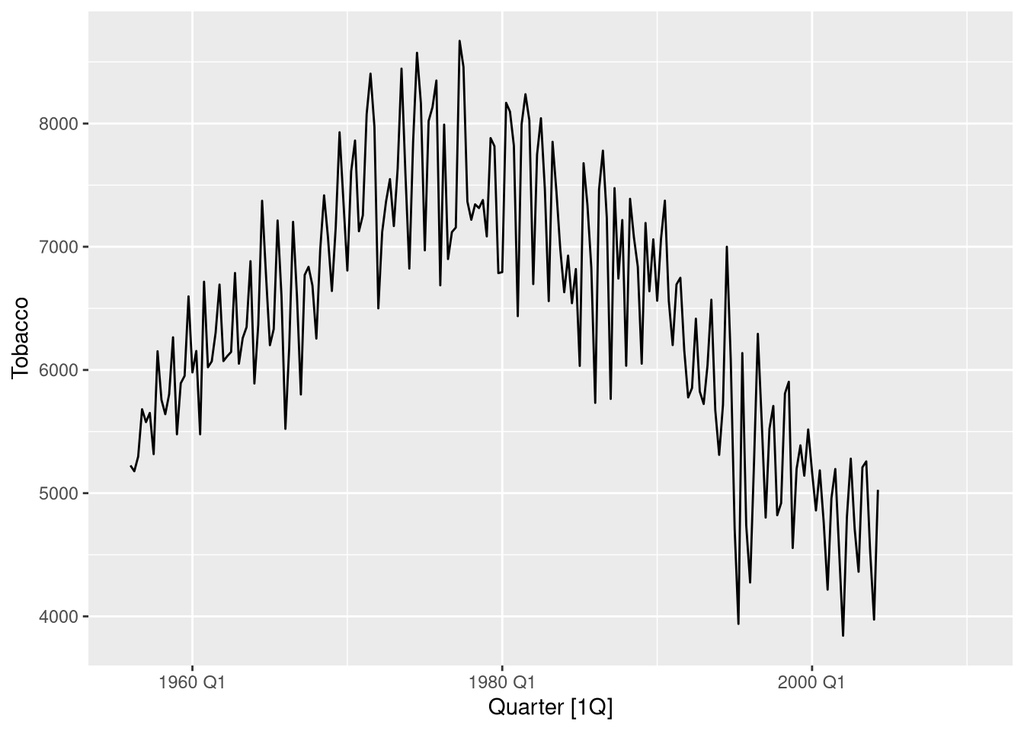

```r
p1 <- aus_production |>
  autoplot(Tobacco)

p1
```

#### We’ll discuss potential solutions during the live session.

```r
The variance in this series appears to be mostly constant across different
levels of the series, perhaps a bit lower initially. It then increases with the
level, but the level later decreases again without a corresponding reduction in
the variance of the data. This does not match the multiplicative pattern, in
which the variance is proportional to the level of the series (it increases or
decreases along with the level).

Even though the data is slightly heteroskedastic (lower variance at the beginning),
it is not multiplicative in nature, so the Box-Cox transformation may not result
in a substantial improvement.

Let's look at the Guerrero feature.
```

```r
lambda <- aus_production |>
  features(Tobacco, features = guerrero) |>
  pull(lambda_guerrero)

lambda
```

```
[1] 0.9264636
```

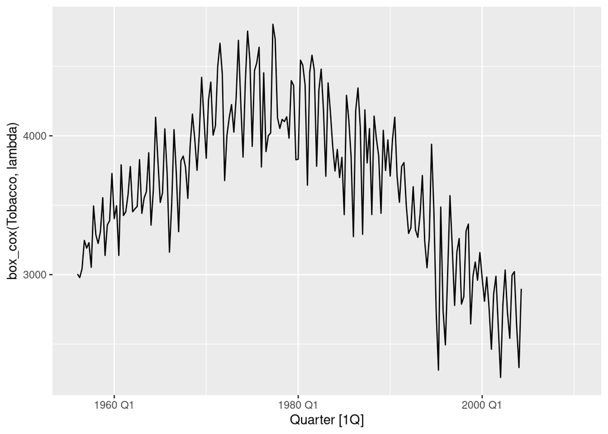

```r
# The value appears to be very close to 1.
p2 <- aus_production |>
  autoplot(box_cox(Tobacco, lambda))

p2
```

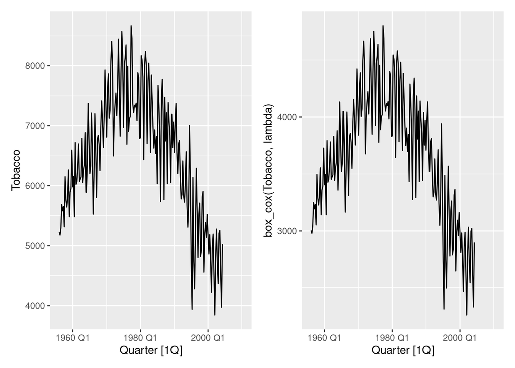

```r
# Comparison
p1 + p2
```

```r
Would you perform this transformation?

No. The value of lambda is very close to 1 (no transformation), so there is no
substantial gain.

Let us plot the original and transformed data together below so that we see
more clearly that there is no substantial gain.

To judge in more quantitative terms whether the transformation is worth it, we
could compare models fitted to the original and transformed variable using
cross-validation.
```

### Example 4. Retail series

```
Plot variable not specified, automatically selected `.vars = Turnover`
```

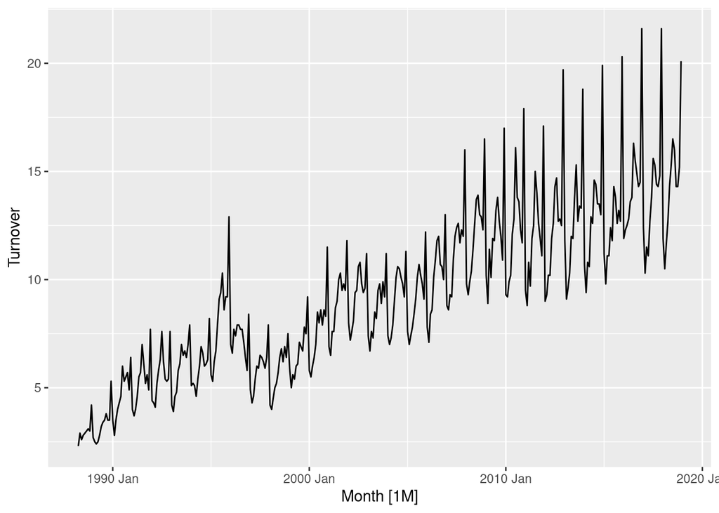

```r
retail_series <- aus_retail |>
  filter(`Series ID` == "A3349767W")

autoplot(retail_series)
```

#### We’ll discuss potential solutions during the live session.

```r
The variation appears to be proportional to the level of the series.

Let's inspect the Guerrero feature.
```

```r
retail_series |>
  features(Turnover, features = guerrero) |>
  pull(lambda_guerrero)
```

```
[1] 0.08303631
```

```r
**Question:** given this value of lambda, what would you do?

Since the value is so close to 0, the sensible choice is a logarithmic
transformation, which is much more interpretable.
```

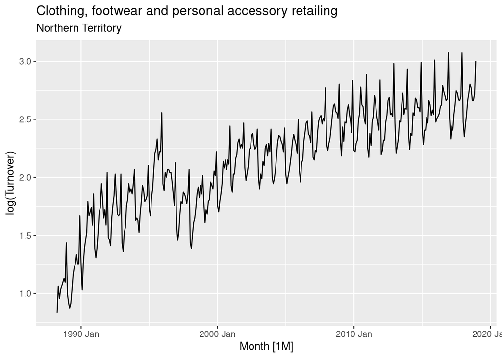

```r
# In this case the transformation is very clearly successful in removing the
# heteroskedasticity in the data, since it was clearly of multiplicative nature.
retail_series |>
  autoplot(log(Turnover)) +
  labs(
    title = retail_series$Industry[1],
    subtitle = retail_series$State[1]
  )
```

# Homework

**NOTE:** For these exercises you need separate datasets that will be uploaded to blackboard. You need the library `readr` as well to read csv files with the function `read_csv`

Judge whether one of the mathematical transformations explained in class is sensible.

If so, specify which transformation you have chosen and provide adequate justification.

## Exercise 1 - Australian imports from Japan

The code below imports the data from the file *australian_imports_japan.csv*, which is in the `data/` folder at the repository root.

The following is a plot of the data.

```r
aus_import_japan <-
  readr::read_csv("data/australian_imports_japan.csv") |>
  mutate(index=yearmonth(index)) |>
  as_tsibble()

aus_import_japan |>
  autoplot() +
  labs(x = "year-month",
       y = "Australian imports from Japan (thousands $)")
```

```
Plot variable not specified, automatically selected `.vars = value`
```

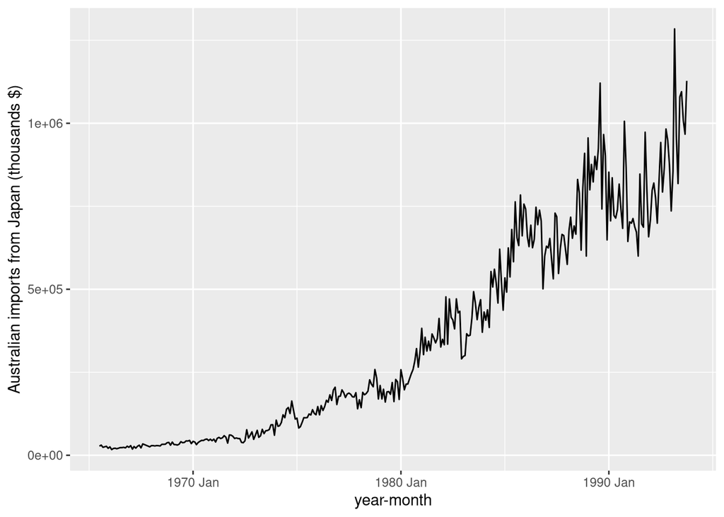

### We’ll discuss potential solutions during the live session.

## Exercise 2 - Private housing units started, USA

The code below imports the data from the file *private_housing_US.csv*, which is in the `data/` folder at the repository root.

The following is a plot of the data.

```r
private_housing_Us <-
  readr::read_csv("data/private_housing_US.csv") |>
  mutate(index=yearmonth(index)) |>
  as_tsibble()

autoplot(private_housing_Us) +
labs(x = "year-month",
     y = "Private housing units started, USA: monthly")
```

```
Plot variable not specified, automatically selected `.vars = value`
```

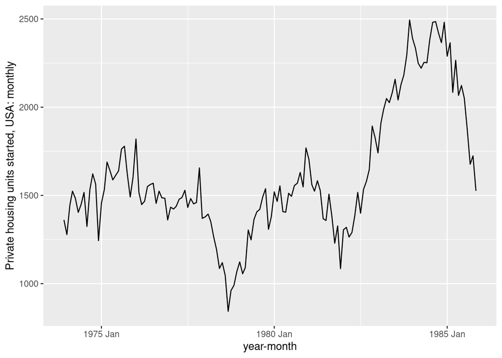

### We’ll discuss potential solutions during the live session.